# STAT1003

Introduction to Data Science

Solution: Workshop 8

# Variable Selection: Body Fat Data

1. Load the data file `BodyFat.RData`

```r
print(load("BodyFat.RData"))
```

```
[1] "TrainBodyFat1" "TestBodyFat1"
```

2. What objects does it contain?

A training set and a test set!

3. Construct a scatterplot matrix of the training **and** test data. Compare them and comment.

Note that because there are 14 variables in the dataset, we need to make the scatterplot matrix a bit bigger than the default size, and we can do so by using the chunk options `fig.width` and `fig.height`. Note these are `knitr/Rmarkdown` options, not `R` code.

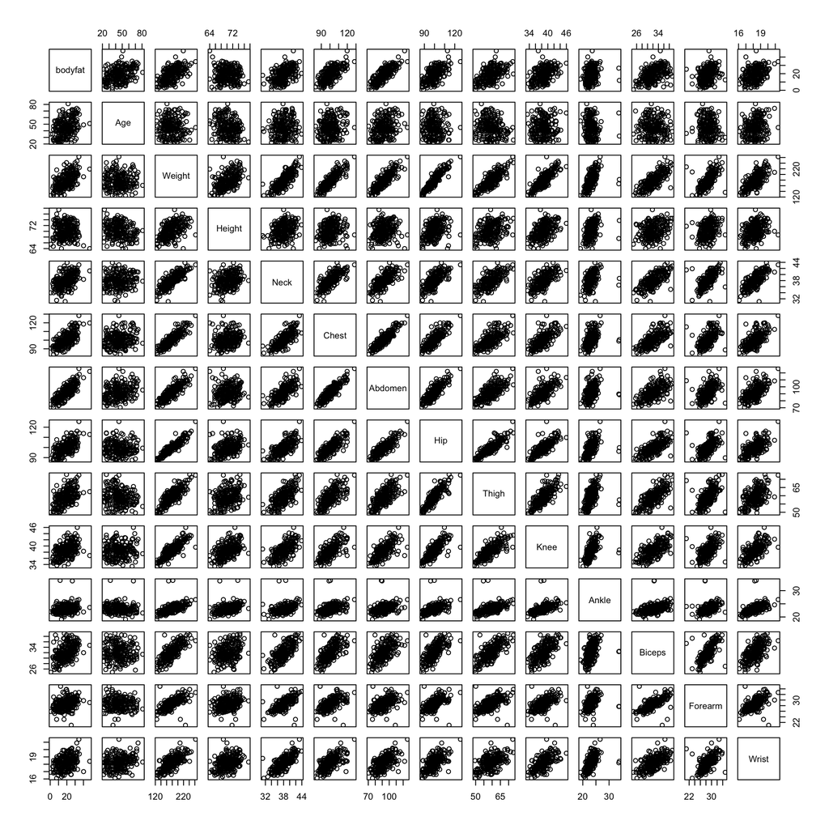

```r
# Training set
pairs(TrainBodyFat1)
```

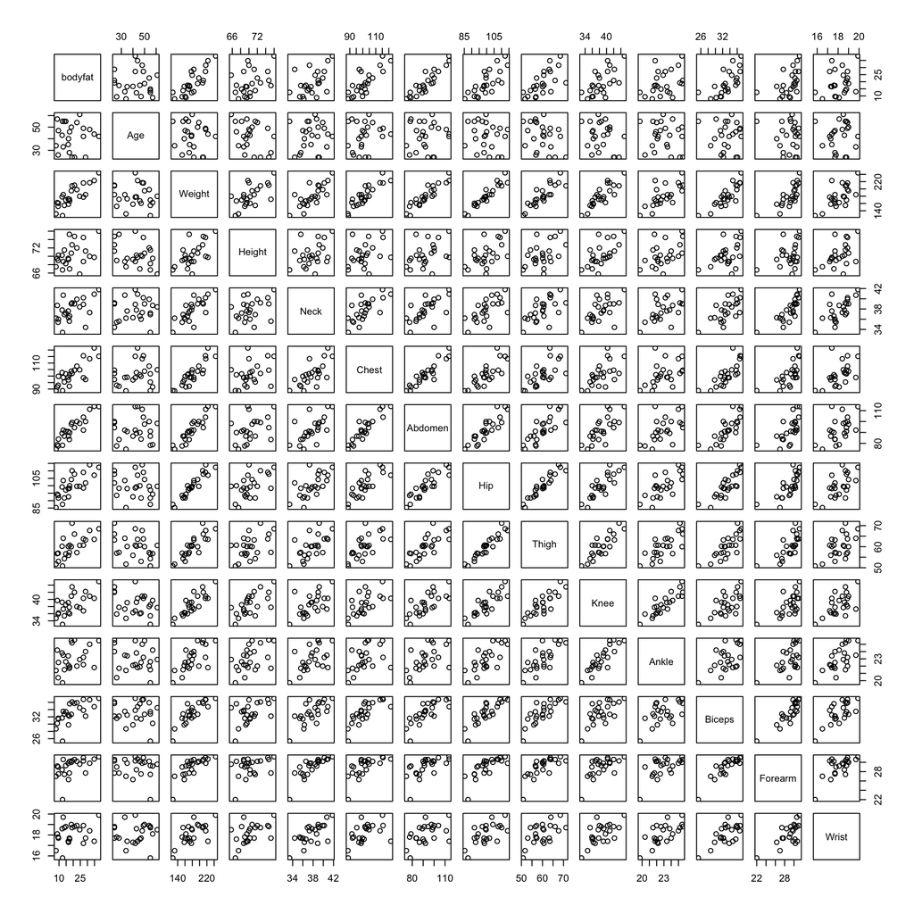

```r
pairs(TestBodyFat1)
```

4. Remove the two obvious outliers from the training set.

There are lots of ways of removing the two individuals outlined above, but a convenient way is to use the function `subset`. See the help file for more details on how to use it. The two individuals to remove have ankle measurements of greater than 30 cm, and we will use this information to keep only those individuals whose ankle measurements are less than 30 cm.

```r
dim(TrainBodyFat1)  # dimension of original training set
```

```
[1] 221  14
```

```r
TrainBodyFat1 <- subset(TrainBodyFat1, Ankle < 30)
```

```r
dim(TrainBodyFat1)  # dimension of training set with two observations removed
```

```
[1] 219  14
```

5. Using the training set, construct a model with only an intercept and a model with all the variables.

The reason we’re going to construct the simplest model possible, and the model with the most number of variables, is so that we can use them in the simplest of all sequential selection methods, forward stepwise regression. Have a look at the lecture notes for a fuller explanation of how it works.

```r
# Model with only intercept
lm0 <- lm(bodyfat ~ 1, data = TrainBodyFat1)
```

```r
# Model with all variables
lmall <- lm(bodyfat ~ ., data = TrainBodyFat1)
```

6. Use forward stepwise regression to select a subset of the variables.

Once we have constructed the models above, we can use them in the function for running forward stepwise selection. The argument `trace = 0` suppresses intermediate output.

```r
lmfwd <- step(lm0, scope = formula(lmall), direction = "forward", trace = 0)
```

```r
summary(lmfwd)
```

```
Call:
lm(formula = bodyfat ~ Abdomen + Weight + Wrist + Biceps, data = TrainBodyFat1)

Residuals:
     Min       1Q   Median       3Q      Max
-10.0819  -3.1413  -0.1155   3.3936   9.1313

Coefficients:
             Estimate Std. Error t value Pr(>|t|)
(Intercept) -32.55819    7.62550  -4.270 2.94e-05 ***
Abdomen       0.97858    0.05909  16.560  < 2e-16 ***
Weight       -0.12828    0.02963  -4.330 2.29e-05 ***
Wrist        -1.42443    0.48061  -2.964  0.00338 **
Biceps        0.31347    0.16245   1.930  0.05498 .
---
Signif. codes:  0 '***' 0.001 '**' 0.01 '*' 0.05 '.' 0.1 ' ' 1

Residual standard error: 4.364 on 214 degrees of freedom
Multiple R-squared:  0.7208,    Adjusted R-squared:  0.7156
F-statistic: 138.1 on 4 and 214 DF,  p-value: < 2.2e-16
```

Remarkably, only four measurements are selected by the procedure. But let’s see how well it predicts body fat….

7. Generate predictions from the forward model and the model with all variables, and compare their RMSEP.

```r
# Predictions from the model with all varaibles
allpred <- predict(lmall, newdata = TestBodyFat1)

# Predictions from the model selected by forward selection
fwdpred <- predict(lmfwd, newdata = TestBodyFat1)
```

```r
Actual <- TestBodyFat1$bodyfat
RMSEP.all <- sqrt(sum((Actual - allpred)^2)/length(Actual))
RMSEP.all
```

```
[1] 3.391678
```

```r
RMSEP.fwd <- sqrt(sum((Actual - fwdpred)^2)/length(Actual))
RMSEP.fwd
```

```
[1] 3.190346
```

The key message here is that more variables in a model don’t lead to better predictions: a model with four variables yields a smaller RMSEP than a model with many more variables.

8. For the models in 7. construct plots of actual versus predicted values. Which one yields a smaller RMSEP?

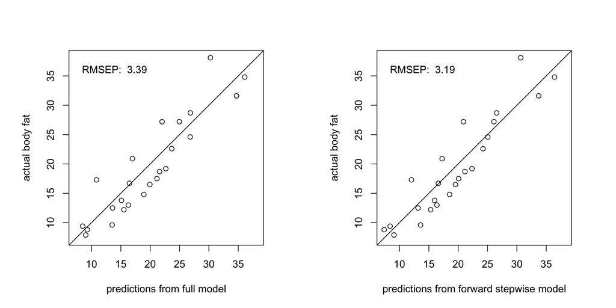

```r
par(mfrow = c(1, 2))  # side-by-side plots
par(pty = "s")  # square plots
Range <- range(c(Actual, allpred, fwdpred))
plot(Actual ~ allpred, xlab = "predictions from full model", ylab = "actual body fat",
    xlim = Range, ylim = Range)
abline(0, 1)
text(Range[1] + 1, Range[2] - 2, labels = paste("RMSEP: ", round(RMSEP.all,
    2)), adj = 0)
plot(Actual ~ fwdpred, xlab = "predictions from forward stepwise model", ylab = "actual body fat",
    xlim = Range, ylim = Range)
text(Range[1] + 1, Range[2] - 2, labels = paste("RMSEP: ", round(RMSEP.fwd,
    2)), adj = 0)
abline(0, 1)
```